# Analyzing Completeness of Spatial Data

-Damian Satterthwaite-Phillips

# Introduction

I worked for a few years as the lead scientist for a mapping project conducted by the Northwest Arctic Borough, Alaska. The goal of the project was to map the land use for subsistence practices–hunting, fishing, trapping, and gathering–by the native Iñupiat people. These data are to be used to inform development in the area with the goal of minimizing damage to subsistence resources.

It was not posssible to interview all of the residents in the area, so we had to base our maps on sample of interiewees. The question naturally arises then: How comprehensive are the data? Can we represent the completeness of the data as a function of the number of interviewees, and use that representation to infer how much more data we might get with additional interviewees?

As it turns out, natural resources are not randomly distributed across the landscape. Some areas are richer than others, and, as such, the subsistence activities of the people are not randomly distributed either. There are clear “hotspots”, good fishing holes, well-known caribou migration corridors, coastal wetlands with nesting birds, and so forth. There is a considerable amount of overlap in the land use of different indiduals, which leads to a case of “diminishing returns” when gathering data. With each additional interviewee, the amount of novel information gradually becomes less and less.

Here I formalize that intuition, and find a function that captures the rate of fall-off accurately.

The code below is in two parts. First, because our raw data from that project are not yet publically available, I have written a script that simulates spatial data, with parameters that can be altered to show more random or more concentrated distributions of land use.

The second part presents the code that actually estimates the rate of information drop-off.

*A fuller description of the methods used in this analysis is provided [HERE](http://phillips-research.com/pdfs/subsistence_mapping_project_methods_Appendix_E.pdf)*.

### Part One: Simulate data

As usual, I like to start with a clean workspace.

```r
rm(list = ls())


#=======================================================================#
#                                                                       #
# SIMULATE SPATIAL DATA:                                                #
# This script generates simulated data for both randomly distributed    #
# data, and data showing a clear preference for certain regions over    #
# others, and allows the user to input different parameters according   #
# to underlying assumptions about the data she wishes to simulate.      #
#  @author: Damian Satterthwaite-Phillips <damiansp@gmail.com>          #
#  @version: 26 Oct 2015                                                #
#                                                                       #
#=======================================================================#


# Generate a random matrix intended to show an individual's land use
# @param cellsPerSide: the number of rows and columns of the matrix
# @param meanLocations: the mean number of unique search areas in the
#                       population; the number of actual areas will be
#                       randomly generated as a Poisson process with lambda =
#                       meanLocations
# @param graph: if true a graphical output of the matrix wil be generated
# @return: a matrix with 1s in the simulated "use areas" and 0s elsewhere
rMatrix = function(cellsPerSide = 10, meanLocations = 10, graph = T) {
    m = matrix(0, nrow = cellsPerSide, ncol = cellsPerSide)

    # Determine the number of use locations as a Poisson random variable
    n = rpois(1, meanLocations)

    # randomly distribute the n locations in the matrix
    locations = sample(1:cellsPerSide^2, n)
    m[locations] = 1

    if (graph == T) {
        # set graph to no margins
        par(mar = c(0, 0, 0, 0))
        image(m)
    }

    return (m)
}

# Helper functions:
# calculate euclidean distance between two cells
# @params: i1, j1 = [i, j] indices of cell one
# @params: i2, j2 = [i, j] indices of cell two
# @return: euclidean distance between cells in cell units
distance = function(i1, j1, i2, j2) {
    return(sqrt((i1 - i2)^2 + (j1 - j2)^2))
}

# Generate a matrix intended to show an individual's land use, with a greater
# probability of using "hot spots"
# @params cellsPerSide, meanLocations, graph: as above
# @param falloff: the rate at which preference for a hotspot decreases with
#                 distance (should be a value between 0 and 1); see lines
#                 <<78 - 83>> for details.
# @param hotSpotLocations: the cell locations indicating the hotspots (this
#                          must be specified so that it is consistent for all
#                          simulated individuals); this is expressed as a
#                          vector of length between 1 and cellsPerSide^2
hotspotProbMatrix = function(cellsPerSide = 10, falloff = 0.7,
                             hotSpotLocations = list(c(1, 1), c(3, 3),
                                                     c(5, 7)),
                             graph = T) {

    m = matrix(0, nrow = cellsPerSide, ncol = cellsPerSide)

    # Initiate a matrix of probabilities with a value of 1 at hotspots, and 0
    # elsewhere
    mProbs = m
    for (hs in hotSpotLocations) {
        mProbs[hs[1], hs[2]] = 1
    }

    # For any given cell, [i, j], determine the distance to the nearest
    # hotspot
    distToNearestHotspot = function(i, j) {
        minDist = Inf
        for (hs in hotSpotLocations) {
            dist = distance(i, j, hs[1], hs[2])
            if (dist < minDist) {
                minDist = dist
            }
        }

        return(minDist)
    }

    # Assign weights to all cells in matrix.
    # For each unit cell away from a hot spot, the weight is scaled by a
    # factor of <falloff>
    # e.g., hs = 1, then at a distance 1, weight = 1*<falloff>, at distance
    # 2, weight = 1*<falloff>^2, or more generally,
    # weight = <falloff>^distance
    for (i in 1:cellsPerSide) {
        for (j in 1:cellsPerSide) {
            dist = distToNearestHotspot(i, j)
            mProbs[i, j] = falloff^dist
        }
    }

    # Scale mProbs so all cells sum to 1
    mProbs = mProbs / sum(mProbs)

    if (graph == T) {
        par(mar = c(0, 0, 0, 0))
        image(mProbs)
    }

    return (mProbs)
}
```

Just to demonstrate, here are some test-runs with different parameters.

```r
# Tests:
hspM = hotspotProbMatrix()
hspM = hotspotProbMatrix(
    cellsPerSide = 20, falloff = 0.95,
    hotSpotLocations = list(c(1, 1), c(2, 3), c(5, 7), c(11, 13), c(17, 19))
)
```

[output not shown]

In these heat maps, the intensity of the color can be thought of as matching the intensity of land use: red areas are areas use by few people, orange intermediate, and yellow and white are high-use areas.

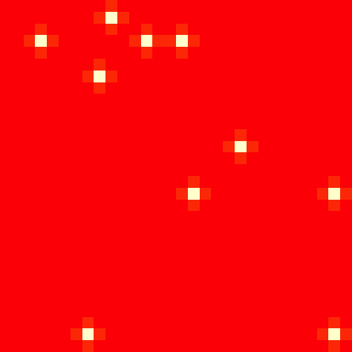

```r
# Simulate one individuals data using a given hotspot probability matrix
# @param hsProbMatrix: the output matrix from hotspotProbMatrix()
# @param meanLocations: the population mean number of locations; the number
#                       for any individual run will be a Poisson random
#                       variable with mean (lambda) = meanLocations
# @graph: if TRUE, graphic output will be generated
# @return: a matrix of the individuals simulated use areas
hotspotMatrix = function(hsProbMatrix, meanLocations = 10,
                         graph = T) {
    # Number of unique locations for a single simulated individual
    n = rpois(1, meanLocations)
    m = hsProbMatrix * 0

    locations = sample(1:prod(dim(m)), n, prob = hsProbMatrix)

    m[locations] = 1

    if (graph == T) {
        # set graph to no margins
        par(mar = c(0, 0, 0, 0))
        image(m)
    }

    return (m)
}



# Create n = 50 random matrices and 20 "hot spot" matices, and store each to
# a list.  Each hot spot matrix will have hs = 10 hotspots, and indiviuals
# will have meanLocs = 10 locations on average. Matrices will be 30 x 30
set.seed(123)
n = 50
hs = meanLocs = 10
mdim = 30

rMatrices = list()
hsMatrices = list()

# randomly generate hotspots
hsLocations = list()
for (i in 1:hs) {
    hsLocations[[i]] = sample(30, 2, T)
}

hsProbMatrix = hotspotProbMatrix(cellsPerSide = mdim, falloff = 0.2,
                                 hotSpotLocations = hsLocations)
```

For this simulation, the above graphic represents the regional hot-spots that the set of 50 individuals are simulated using, showing a preference for the white regions of the grid.

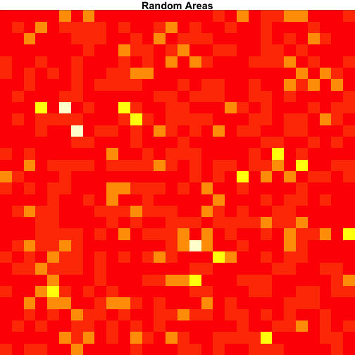

```r
for (i in 1:n) {
    mName = paste('m', i, sep = '')
    rMatrices[[mName]] = rMatrix(cellsPerSide = mdim,
                                 meanLocations = meanLocs, graph = F)
    hsMatrices[[mName]] = hotspotMatrix(hsProbMatrix = hsProbMatrix,
                                        meanLocations = meanLocs, graph = F)
}

# Plot the sum of all matrices in each group.
rMatrixSum = rMatrices[[1]]
hsMatrixSum = hsMatrices[[1]]

for (i in 2:n) {
    rMatrixSum = rMatrixSum + rMatrices[[i]]
    hsMatrixSum = hsMatrixSum + hsMatrices[[i]]
}

# Plot the sum of all individuals, simulating the "population" use area
#quartz()
#par(mfrow = c(1, 2))
par(mar = c(0, 0, 1, 0))
image(rMatrixSum, main = 'Random Areas')
```

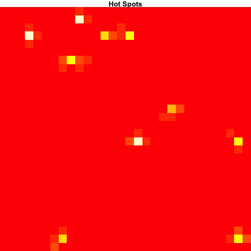

```r
image(hsMatrixSum, main = 'Hot Spots', yaxt = 'n')
```

```r
#================== END OF SIMULATION SCRIPT =================#
```

The last images show simulated data for two extreme cases: total random subsistence use areas, and areas showing a clear preference for a few hot spots.

Next I show how the rate of information dimishes as a function of the number of interviewees.

## Part Two: Analysis

The first part of the script assumes that real data are being used instead of simulated data and explain how the data should be formatted. Here, because I am running this program through knitr to create the webpage, they are commented out sot that they will not be run.

```r
#=======================================================================#
#                                                                       #
#  ANALYSIS OF COMPLETENESS:                                            #
#  This script runs the analysis of completeness described in Methods   #
#  Section 2.1.1.6.2 “Analysis of Data Sufficiency”                     #
#  @input: a series of .csv files (with no headers or row names),       #
#          each equivalent to a raster representing the union of all    #
#        polygons for a given interviewee, and for which 1              #
#        indicates the area enclosed in the polgyon, and 0              #
#        indicates area outside.                                        #
#  @output: a vector of values c(totalArea, a1, a2, ..., an), where     #
#           total area indicates the total number of cells in the       #
#       matrix, a1 is the area of the polygons enclosed by the          #
#       first randomly chosen matrix, a2 = the area enclosed by         #
#       the second randomly chosen matrix minus the area of a1          #
#       (or the new area found in the matrix), a3 = randomly            #
#       selected 3rd matrix - a1 - a2 (or the new area found in         #
#       the matrix), etc.                                               #
#           An optional graphical output like those in Figs 2.4-2.5f    #
#       may also be generated, showing the best fitting                 #
#       exponential decay model.                                        #
#  @author: Damian Satterthwaite-Phillips <damiansp@gmail.com>          #
#  @version: 26 Oct 2015                                                #
#                                                                       #
#=======================================================================#

# Data: supply paths to source files (e.g.,
# '~/Desktop/data/interviewee1.csv'; on Windows machines backslashes
# may be necessary instead:
# 'C:\Desktop\data\interviewee1.csv'


# NOTE: If using real data begin here (line 36). If using the
# simulated data, skip ahead to line 59

# Source file 1 (a single interviewee’s data):
#s1 = as.matrix(read.csv('Path to file for first interview', header = F))
# In some cases this results in a final column of NAs being added;
# check with:
#head(s1)

# If so, remove the NA column:
#s1 = s1[,-dim(s1)[2]]

# Source file 2
#s2 = as.matrix(read.csv( 'Path to file for second interview', header= F ))
#head(s2)

# If final NA column present, remove:
#s2 = s2[,-dim(s2)[2]]

# ...repeat for all input files for a given study site

#siteList = list(s1,s2, # Enter all such matrices
#          )


#================= USING SIMULATED DATA, START HERE =================#
```

Using the simulated data, we enter the script here and continue…

```r
# For the purposes of the simualted data, we skip the above steps (commented
# out), and instead set our siteList to either rMatrices or hsMatrices
siteList = rMatrices


# The following code assumes that all input matrices are of the same
# dimension. If not, new input files will have to be created to correct
# for this.
# Check that all are of the same dimension:
for (i in 1:(length(siteList))) {
    print(dim(siteList[[i]]))
}
```

```
## [1] 30 30
## [1] 30 30
## [1] 30 30
## ... All the same!
```

```r
# The following are helper functions necessary to perform the
# computations.

# Determine total number of cells in matrix
totalArea = function(M) {
    dim(M)[1] * dim(M)[2]
}

# Calculate the number of cells with value 1 in newM that are not
# already in existingM
newArea = function(existingM, newM) {
    sum(newM & !existingM)
}

# Create a matrix that is the union of the existingM and the newM: any
#cell that is 1 in either existingM or newM (or both) is 1; any cell
# that is 0 in both remains 0
union = function(existingM, newM) {
    1 * (existingM | newM)    # Multiplication by 1 coerces output to
                              # numeric instead of boolean
}

# Function to calculate standard error for a sample mean
se = function(x) {
    sd(x) / sqrt(length(x))
}

# Create output of new areas added from each matrix in listOfMs
# @output: c(totalArea, a1, a2, ..., an) as explained above
newAreas = function(listOfMs, graph = T) {
    # Create an initial all-0 matrix
    m0 = listOfMs[[1]] - listOfMs[[1]]

    # Initialize an output placeholder
    out = c(totalArea(m0))

    # Initialize a matrix to be the union of all matrices added
    unionM = m0

    # Create a placeholder to store the union at each step
    unionList = list(unionM)

    for (i in listOfMs) {
     # Calculate the new area contributed by the next matrix
     out = c(out, newArea(unionM, i))

     # Update unionM by adding next matrix; update unionList
     unionM = union(unionM, i)
     unionList = list(unionList, unionM)
    }

    cumArea = cumsum(out[2:(length(out))])
    if (graph == T) {
     plot(cumArea, type='l', ylab = 'Cumulative Area',
          xlab = 'Number of Maps Added')
     abline(h = out[1], col=2)
     legend('topleft', lty = 1, col = 2, legend = 'Total Map Area',
            bg = 'white')
    }

    list(mapArea = out[1], addedArea = out[2:(length(out))],
         cumArea = cumArea, combinedMaps = unionList)
}
```

The above code was just reading in data and creating the helper functions that will manipulate the data matrices. Now we get to the heart of the analysis.

This script uses non-linear models (nlm), whose performance can depend on the users's ability to specify good initial values. Failure to do so may lead to failure of the nlm function to converge on a solution. As such I have provided two different functions, one of which is commented out in the code below. The code executed here is the better-fitting function, but harder to get to converge, so the commented out function may be used instead. The latter is a simpler exponential-decay model. Unless the data are truly randomly distributed, it results in a poorer fit, but it is easier to get it to converge, so it is provided for that reason.

A detailed explanation of the methods can be found [here](http://phillips-research.com/pdfs/subsistence_mapping_project_methods_Appendix_E.pdf)

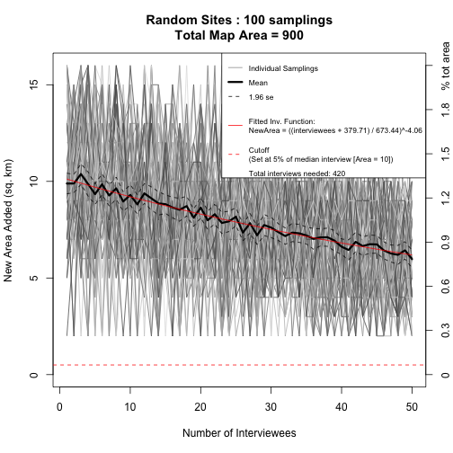

```
## $additionalData
##     totalArea a1 a2 a3 a4 a5 a6 a7 a8 a9 a10 a11 a12 a13 a14 a15 a16 a17
## 1         900 16 13  6 10  7  9  9  9  8  11  11  10  11   9  12   8   7
## 2         900  9 10 14  2 13  9  6 15  8   9   9  13  13  10   7  10  11
## 3         900  8 11  9 11  4 10  6 10  9   9   8  16   8  10  11  14  11
## ...additional rows deleted (these are the grey lines that are the raw,
## permuted data.
##
## $meanAdded
##   X16L   X13L    X6L   X10L    X7L    X9L  X9L.1  X9L.2    X8L   X11L
##   9.89   9.89  10.38   9.87   9.34   9.85   9.27   9.64   8.96   9.30
## ...additional rows deleted (these are the mean values plotted as the solid
## black line)
##
## $fit
##
## Formula: means[2:nCols] ~ I(((interviewees + c)/d)^e)
##
## Parameters:
##   Estimate Std. Error t value Pr(>|t|)
## c  379.705    700.621   0.542    0.590
## d  673.439    570.178   1.181    0.244
## e   -4.058      7.059  -0.575    0.568
##
## Residual standard error: 0.2241 on 47 degrees of freedom
##
## Number of iterations to convergence: 22
## Achieved convergence tolerance: 1.984e-06
##
##
## $totalInterviewsNeeded
## [1] 420
```

```r
# Main function--the completeness analysis: Repeat the newAreas()
# function <iterations> times, randomizing the list each time.
# Write cumArea values to a data.frame for analysis.
# Plot all cumArea plots along with mean and 2se.
# Determine the best exponential decay model, and plot.
# @param locale: name of the location
# @param listOfMs: a list of matrices, each of which should have the
#            same dimensions
# @param iterations: number of random permutations over which to
#              average the behavior--recommend a small number
#              (~10) for initial testing
# @param graph: if true, displays graphical output
# @params cStart, dStart, eStart: initial coefficients to pass to the nls
#                                 function; some trial and error may be
#                                 needed to get the function to converge.
# @param limitPercent: Cutoff threshold (see text).  Existing code
#                represents this as a percent of the information
#                in the median input matrix.
# NOTE: Although not appropriate for data that are not randomly distributed,
# the exponential function is typically easier to fit to the data,
# particularly when suitable parameter estimates cannot be found to get the
# nls function to converge. Hence the exponential model is also provided
# below (commented out).
completeness = function(locale = '', listOfMs, iterations, graph = T,
                        limitPercent = 1, cStart = 5, dStart = NULL,
                        eStart = -1) {

    # Create placeholder for output
    out.df = data.frame()

    for (i in 1:iterations) {
        # Print progress after every 10 iterations
        if (i %% 10 == 0) {
            cat('Progress: ', 100 * i / iterations, '%\n', sep = '')
        }

        # Randomize list
        currentList = sample(listOfMs)

        # Run newAreas
        nextData = newAreas(currentList, graph = F)

        # Append cumArea data to out.df
        out.df = rbind(out.df, c(nextData$mapArea, nextData$addedArea))
    }

    nCols = dim(out.df)[2]
    means = apply(out.df, 2, mean)
    ses = apply(out.df, 2, se)
    totalArea = out.df[1,1]
    meanCumArea = sum(out.df[,2:nCols]) / iterations
    cutoff = (limitPercent / 100) * median(out.df[,2])

    # Model the information added as an exponential function of the
    # number of interviewees
    interviewees = 1:(nCols - 1)
#    exp.mod = nls( means[2:nCols] ~ a * exp(-b * (interviewees)),
#                      start = list(a = means[2], b = 0.2) )

#    a = coef(exp.mod)[1]
#    b = coef(exp.mod)[2]

    # Model the information as an inverse function
    # initialize dStart such that y-intercept = means[2]
    if (is.null(dStart)) {
        dStart = cStart / means[2]^(1 / eStart)
    }

    inv.mod = nls( means[2:nCols] ~ I(((interviewees + c) / d)^e),
                   start = list(c = cStart, d = dStart, e = eStart),
                   trace = T )

    c = coef(inv.mod)[1]    # bigger c translates function farther left
    d = coef(inv.mod)[2]
    e = coef(inv.mod)[3]


    i = 1
#    newAreaAdded = a * exp(-b * 1)
    newAreaAdded = ((i + c) / d)^e

#    while (newAreaAdded > cutoff) {
#       i = i + 1
#           newAreaAdded = a * exp(-b * i)
#    }

    while (newAreaAdded > cutoff) {
        i = i + 1
        newAreaAdded = ((i + c) / d)^e
    }


    interviewsNeeded = i



    if (graph == T) {
        # Create a palette of grey-tones to use to plot individual samples
        palette = c('#555555', '#666666', '#777777','#888888','#999999',
                    '#AAAAAA', '#BBBBBB', '#CCCCCC', '#DDDDDD')

        mainTitle = paste(locale, ':', iterations,
                          'samplings\nTotal Map Area =', totalArea)

        # Plot individual samplings
        matplot(t(out.df[,2:nCols]), type = 'l', lty = 1, col = palette,
                ylim = c(0, max(out.df[,2:nCols])),
                xlab = 'Number of Interviewees',
                ylab = 'New Area Added (sq. km)', main = mainTitle)

        # Add lines for mean behavior and 96% CI for mean
        lines(means[2:nCols], lwd = 3)
        lines(means[2:nCols] + 1.96 * ses[2:nCols], lty = 2)
        lines(means[2:nCols] - 1.96 * ses[2:nCols], lty = 2)

        # Plot exponential function
#       lines(interviewees, a * exp(-b*(interviewees)), col = 2)

        # Plot inverse function
        lines(interviewees, ((interviewees + c) / d)^e, col = 2)

        # Add threshold line
        abline(h = cutoff, lty = 2, col = 2)

        # Add legend
        # Exp. mod.
#       legend( 'topright', lty=c(1, 1, 2, 1, 1, 1, 2, 1),
#                   lwd=c(1, 3, 1, 1, 1, 1, 1, 1),
#                 col = c('#999999', 1, 1, 'white', 2, 'white', 2, 'white'),
#                 legend = c('Individual Samplings', 'Mean', '1.96 se', '',
#                            paste("Fitted Inv. Function:\nNewArea = ",
#                                  round(a, 2), 'e^(',
#                                  round(b, 2), ')', sep=''),
#                            '',
#                            paste('Cutoff \n(Set at ', limitPercent,
#                                  '% of median interview [Area = ',
#                                  median(out.df[,2]),'])', sep=''),
#                            paste('\nTotal interviews needed: ',
#                              interviewsNeeded, sep='') ),
#                 bg = 'white', cex = 0.7 )

        # Inverse mod.
        legend( 'topright', lty=c(1, 1, 2, 1, 1, 1, 2, 1),
                lwd=c(1, 3, 1, 1, 1, 1, 1, 1),
                col = c('#999999', 1, 1, 'white', 2, 'white', 2, 'white'),
                legend = c('Individual Samplings', 'Mean', '1.96 se', '',
                           paste("Fitted Inv. Function:\nNewArea = ",
                                 '((interviewees + ', round(c, 2), ') / ',
                                 round(d, 2), ')^', round(e, 2), sep=''),
                           '',
                           paste('Cutoff \n(Set at ', limitPercent,
                                 '% of median interview [Area = ',
                                 median(out.df[,2]),'])', sep=''),
                           paste('\nTotal interviews needed: ',
                                 interviewsNeeded, sep='') ),
                bg = 'white', cex = 0.7 )

     # Add an axis on the right side indicating area as a % of the
     # total area
     axis(side = 4, at = seq(0, max(out.df[,2:nCols]), length.out = 8),
          labels = c(
              as.character(round(
                  seq(0, 100*max(out.df[,2:nCols]) / totalArea,
                      length.out = 7),
                  1)),
              '% tot area') )

    }

    names(out.df)[1] = 'totalArea'
    names(out.df)[2:nCols] = paste('a', 1:(nCols - 1), sep = '')

    list(additionalData = out.df, meanAdded = means[2:nCols],
         fit = summary(inv.mod), totalInterviewsNeeded = i )
}

# Run the analysis:
set.seed(123)
completeness(locale = 'Random Sites', listOfMs = rMatrices,
             iterations = 100, limitPercent = 5, cStart = 1000,
             eStart = -30)
```

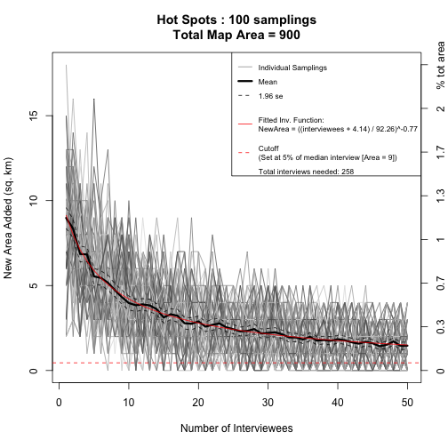

```
## $additionalData
## ...console output omitted here...
##
## $fit
##
## Formula: means[2:nCols] ~ I(((interviewees + c)/d)^e)
##
## Parameters:
##   Estimate Std. Error t value Pr(>|t|)
## c  4.14061    0.49227   8.411 6.24e-11 ***
## d 92.25602    3.63267  25.396  < 2e-16 ***
## e -0.76662    0.03153 -24.314  < 2e-16 ***
## ---
## Signif. codes:  0 '***' 0.001 '**' 0.01 '*' 0.05 '.' 0.1 ' ' 1
##
## Residual standard error: 0.1525 on 47 degrees of freedom
##
## Number of iterations to convergence: 10
## Achieved convergence tolerance: 3.395e-07
##
##
## $totalInterviewsNeeded
## [1] 258
```

```r
# Repeat with hotspot matrices
#quartz()
completeness(locale = 'Hot Spots', listOfMs = hsMatrices,
             iterations = 100, limitPercent = 5, cStart = 1000,
             eStart = -30)
```

In the output there is an arbitrary threshold plotted as the point at which novel information per interviewee is deemed to little to justify gathering additional data. The function itself is also provided, as is the estimated number of interviewees needed to reach the threshold. By integrating the function from the number of actual interviees to infinity, the amount of total missing data can also be estimated.

The following code plots the collective land use of the entire sample, along with the empirical confidence interval.

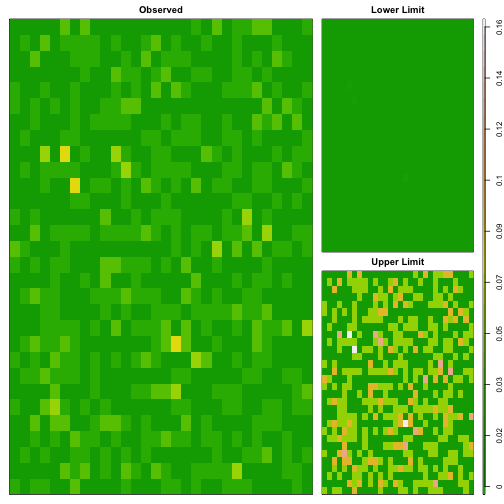

```
## $observed
##       [,1] [,2] [,3] [,4] [,5] [,6] [,7] [,8] [,9] [,10] [,11] [,12] [,13]
##  [1,] 0.02 0.00 0.00 0.00 0.00 0.02 0.00 0.00 0.02  0.00  0.00  0.00  0.00
##  [2,] 0.00 0.00 0.02 0.00 0.00 0.00 0.00 0.02 0.00  0.02  0.00  0.00  0.02
##  [3,] 0.02 0.00 0.00 0.02 0.04 0.00 0.00 0.02 0.02  0.04  0.00  0.00  0.04
##  [4,] 0.02 0.00 0.02 0.00 0.00 0.04 0.00 0.04 0.00  0.02  0.02  0.02  0.02
##  [5,] 0.00 0.00 0.00 0.02 0.04 0.06 0.04 0.02 0.04  0.02  0.02  0.02  0.02
## ...additional rows omitted...
##
## $lower
##       [,1] [,2] [,3] [,4] [,5] [,6] [,7] [,8] [,9]       [,10] [,11] [,12]
##  [1,]    0    0    0    0    0    0    0    0    0 0.000000000     0     0
##  [2,]    0    0    0    0    0    0    0    0    0 0.000000000     0     0
##  [3,]    0    0    0    0    0    0    0    0    0 0.000000000     0     0
##  [4,]    0    0    0    0    0    0    0    0    0 0.000000000     0     0
##  [5,]    0    0    0    0    0    0    0    0    0 0.000000000     0     0
##  ...
##
## $upper
##             [,1]       [,2]       [,3]       [,4]       [,5]       [,6]
##  [1,] 0.05880531 0.00000000 0.00000000 0.00000000 0.00000000 0.05880531
##  [2,] 0.00000000 0.00000000 0.05880531 0.00000000 0.00000000 0.00000000
##  [3,] 0.05880531 0.00000000 0.00000000 0.05880531 0.09431612 0.00000000
##  [4,] 0.05880531 0.00000000 0.05880531 0.00000000 0.00000000 0.09431612
##  [5,] 0.00000000 0.00000000 0.00000000 0.05880531 0.09431612 0.12582678
##  ...
```

```r
# Helper function: determine the standard error of a percentage of successes
# given n samples
# @param p: probability of success
# @param n: number of samples
# @return: the standard error of the estimate
# NOTE: estimates will not be reliable if the observed p is 0
se = function(p, n) {
    return (sqrt(p * (1 - p) / n))
}

# The estimated percentage of the population using any single cell
# Determines the percentage of users at each cell in the grid, along with the
# empirical confidence interval at each location.
# @param ci: the desired confidence interval; e.g. 0.95 = 95% confidence
#            interval
# @param ms: list of matrices of individual uses in the sample
# @param graph: if TRUE, provides visual output
# @param col: the color palette and number of unique colors to use in the
#             output graph
# @return: matrices of the observed percentages of use for the entire sample,
#          along with the upper and lower confidence levels
ciMatrices = function(ci = 0.95, ms, graph = T, col = terrain.colors(100)) {
    # Obtain Z values for quantiles for the given CI
    seQ = qnorm(p = c((1 - ci) / 2, (1 + ci) / 2))

    # sum matrices
    mSum = ms[[1]]
    for (i in 2:length(ms)) {
        mSum = mSum + ms[[i]]
    }

    # create a matrix of proportions for each cell (= p)
    mProp = mSum / length(ms)

    # and SEs for each cell
    mSE = se(mProp, length(ms))

    # lower and upper limits of confidence interval
    mLL = mProp + seQ[1] * mSE
    mLL[mLL < 0] = 0
    mUL = mProp + seQ[2] * mSE
    mUL[mUL > 1] = 1
    zl = range(mLL, mUL)

    if (graph == T) {
        n = dim(mProp)[1]

        par(mar = c(1, 1, 2, 1))
        layout(matrix(c(1, 1, 1, 1, 2, 3, 4, 4), ncol = 4),
               widths = c(1, 1, 1, 0.13), heights =  c(1, 1, 1, 1))
        image(mProp, xaxt = 'n', yaxt = 'n', main = 'Observed',
              col = col, zlim = zl)

        par(mar = c(0, 0, 2, 1))
        image(mLL, xaxt = 'n', yaxt = 'n', main = 'Lower Limit', col = col,
              zlim = zl)
        par(mar = c(1, 0, 2, 1))
        image(mUL, xaxt = 'n', yaxt = 'n', main = 'Upper Limit', col = col,
              zlim = zl)

        # Create a key for color values
        vals = seq(min(zl), max(zl), length = n)
        keyM = matrix(vals, nrow = 1)
        par(mar = c(1, 0, 2, 2))
        image(keyM, col = col, zlim = zl, xaxt = 'n', yaxt = 'n')
        ticsAt = seq(0, 1, length = 10)
        ticVals = round(seq(min(zl), max(zl), length = 10), 2)
        axis(side = 4, at = ticsAt, labels = ticVals)
    }

    return (list(observed = mProp, lower = mLL, upper = mUL))

}


ciMatrices(0.95, rMatrices, T)
```

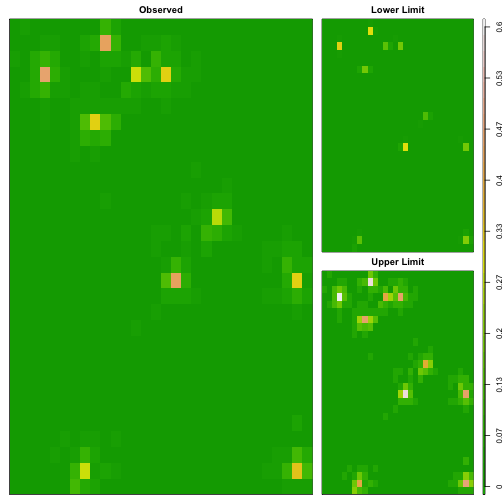

```
...console output omitted...
```

```r
ciMatrices(0.95, hsMatrices, T)
```

```r
#================== END OF SCRIPT =================#
```

The final output graph shows the value at each cell color-coded as the percentage of interviewees using each grid cell. Additionally the uppper and lower confidence intervals (CI) at each cell are provided as well. The user can specify the preferred CI, the image uses 95%. The values at each cell are available in the returned data. For example in the console output above, for grid cell [1, 1], (this refers to the lower left corner of the images), 2% of the actual interviewees used this grid ("observed") value, and our 95% CI for this cell is between 0% and 5.9%. ("lower" and "upper" respectively). We can also see that the regions of highest use are used by 30 - 60% of the population.

When our data become publicly available, I will update the images to show real data. They'll be a whole lot cooler to look at, as geographic boundaries like lakes and coastlines are readily observable.